# Clustering and Dimensionality Reduction with Opel Corsa Car Dataset

Alparslan Erol

06/01/2021

# Introduction

Data clustering is the assignment of objects to homogeneous groups (called clusters) while making sure that objects in different groups are not similar. Clustering is considered an unsupervised task as it aims to describe the hidden structure of the objects. Each object is described by a set of characters called features. The first step of dividing objects into clusters is to define the distance between the different objects. Defining an adequate distance measure is crucial for the success of the clustering process.

In the field of machine learning, it is useful to apply a process called dimensionality reduction to highly dimensional data. The purpose of this process is to reduce the number of features under consideration, where each feature is a dimension that partly represents the objects.

Dimensionality reduction can be executed using two different methods:  
- Selecting from the existing features (feature selection)  
- Extracting new features by combining the existing features (feature extraction)

[figure not shown]

opel

In this paper, Opel Corsa dataset is used to analysis and it is thought to be work both in different data clustering and dimentionality reduction approaches will give more insight about how to use these approaches together in daily analysis. Analysis divided into three main parts.

**1. Exploratory Data analysis**  
- Statistical Analysis, Visualization, Data Transformation  
**2. Dimensonality Reduction**  
- Drop no variance features  
- Correlation analysis to check similarity between features  
- PCA(Principal Component Analysis) for dimentionality reduction + Feature Engineering  
**3. Clustering**  
- K-Means  
- PAM  
- Hierarchical Clustering

# Exploratory Data analysis

In this part, you can observe statistical analysis of the given data for analysis with some visualization parts to give an insight about distribution of the data.

> For data transformation, chr type features converted into factor and inputed with some numeric value which categorize this features.

## Loading Packages

```r
packages<-function(x){
  x<-as.character(match.call()[[2]])
  if (!require(x,character.only=TRUE)){
    install.packages(pkgs=x,repos="http://cran.r-project.org")
    require(x,character.only=TRUE)
  }
}

packages(tidyverse)
packages(dplyr)
packages(ggplot2)
packages(broom)
packages(rpart)
packages(rpart.plot)
packages(rattle)
packages(cowplot)
packages(knitr)
packages(corrplot)
packages(gridExtra)
packages(GGally)
packages(cluster) # clustering algorithms
packages(factoextra) # clustering algorithms & visualization
packages(funModeling)
packages(Hmisc)
packages(FactoMineR)
packages(factoextra)
packages(plot3D)
```

## Statistical Analysis of Data

```r
cars <- read.csv('C:/Users/ALPARSLAN/Desktop/Alparslan/MERVE/irem&Onur/Project 2/Data_3000.csv', sep=";", dec=".", header=TRUE)
```

### Cars.head()

```r
kable(head(cars))
```

| Price | Brand | Model | Engine | Year | Fuel_Type | Gear_Type | Km | Engine_Power | Engine_Capacity | WD | Color | Warranty | Seller |
| --- | --- | --- | --- | --- | --- | --- | --- | --- | --- | --- | --- | --- | --- |
| 24900 | Opel | Corsa | 1.3 | 2004 | Diesel | Manual | 270000 | 70 | 1248 | Front_2WD | Red | No | Gallery |
| 27500 | Opel | Corsa | 1.2 | 2004 | Gasoline | Manual | 164000 | 75 | 1199 | Front_2WD | Red | No | Gallery |
| 42500 | Opel | Corsa | 1.3 | 2008 | Diesel | Semi Automatic | 300000 | 90 | 1248 | Front_2WD | Grey | No | Gallery |
| 63750 | Opel | Corsa | 1.4 | 2017 | Gasoline | Semi Automatic | 8780 | 90 | 1398 | Front_2WD | Red | Yes | Gallery |
| 25000 | Opel | Corsa | 1.3 | 2004 | Diesel | Manual | 200000 | 70 | 1248 | Front_2WD | Blue | No | Owner |
| 28500 | Opel | Corsa | 1.7 | 2003 | Diesel | Manual | 130000 | 76 | 1601 | Front_2WD | White | Yes | Gallery |

### str(cars)

```r
kable(str(cars))
```

```
## 'data.frame':    2994 obs. of  14 variables:
##  $ Price          : int  24900 27500 42500 63750 25000 28500 29750 19250 37500 21250 ...
##  $ Brand          : chr  "Opel" "Opel" "Opel" "Opel" ...
##  $ Model          : chr  "Corsa" "Corsa" "Corsa" "Corsa" ...
##  $ Engine         : num  1.3 1.2 1.3 1.4 1.3 1.7 1.3 1.2 1.2 1.4 ...
##  $ Year           : int  2004 2004 2008 2017 2004 2003 2011 2000 2007 1999 ...
##  $ Fuel_Type      : chr  "Diesel" "Gasoline" "Diesel" "Gasoline" ...
##  $ Gear_Type      : chr  "Manual" "Manual" "Semi Automatic" "Semi Automatic" ...
##  $ Km             : int  270000 164000 300000 8780 200000 130000 197000 169000 97000 221000 ...
##  $ Engine_Power   : int  70 75 90 90 70 76 75 65 76 90 ...
##  $ Engine_Capacity: int  1248 1199 1248 1398 1248 1601 1248 1199 1201 1389 ...
##  $ WD             : chr  "Front_2WD" "Front_2WD" "Front_2WD" "Front_2WD" ...
##  $ Color          : chr  "Red" "Red" "Grey" "Red" ...
##  $ Warranty       : chr  "No" "No" "No" "Yes" ...
##  $ Seller         : chr  "Gallery" "Gallery" "Gallery" "Gallery" ...
```

[output not shown]

> You can observe that we have character type features. To make an easier analysis, I factorized this features.

### After-Factor str(cars)

```r
cars[sapply(cars, is.character)] <- lapply(cars[sapply(cars, is.character)],as.factor)
kable(str(cars))
```

```
## 'data.frame':    2994 obs. of  14 variables:
##  $ Price          : int  24900 27500 42500 63750 25000 28500 29750 19250 37500 21250 ...
##  $ Brand          : Factor w/ 1 level "Opel": 1 1 1 1 1 1 1 1 1 1 ...
##  $ Model          : Factor w/ 1 level "Corsa": 1 1 1 1 1 1 1 1 1 1 ...
##  $ Engine         : num  1.3 1.2 1.3 1.4 1.3 1.7 1.3 1.2 1.2 1.4 ...
##  $ Year           : int  2004 2004 2008 2017 2004 2003 2011 2000 2007 1999 ...
##  $ Fuel_Type      : Factor w/ 3 levels "Diesel","Gasoline",..: 1 2 1 2 1 1 1 2 2 3 ...
##  $ Gear_Type      : Factor w/ 3 levels "Automatic","Manual",..: 2 2 3 3 2 2 2 2 3 2 ...
##  $ Km             : int  270000 164000 300000 8780 200000 130000 197000 169000 97000 221000 ...
##  $ Engine_Power   : int  70 75 90 90 70 76 75 65 76 90 ...
##  $ Engine_Capacity: int  1248 1199 1248 1398 1248 1601 1248 1199 1201 1389 ...
##  $ WD             : Factor w/ 3 levels "4WD","Back_2WD",..: 3 3 3 3 3 3 3 3 3 3 ...
##  $ Color          : Factor w/ 18 levels "Beige","Black",..: 13 13 8 13 3 17 17 18 3 13 ...
##  $ Warranty       : Factor w/ 2 levels "No","Yes": 1 1 1 2 1 2 1 1 1 1 ...
##  $ Seller         : Factor w/ 2 levels "Gallery","Owner": 1 1 1 1 2 1 1 1 2 2 ...
```

[output not shown]

### Status

```r
status(cars)
```

```
##           variable q_zeros     p_zeros q_na p_na q_inf p_inf    type unique
## 1            Price       0 0.000000000    0    0     0     0 integer    498
## 2            Brand       0 0.000000000    0    0     0     0  factor      1
## 3            Model       0 0.000000000    0    0     0     0  factor      1
## 4           Engine       0 0.000000000    0    0     0     0 numeric      7
## 5             Year       0 0.000000000    0    0     0     0 integer     27
## 6        Fuel_Type       0 0.000000000    0    0     0     0  factor      3
## 7        Gear_Type       0 0.000000000    0    0     0     0  factor      3
## 8               Km       5 0.001670007    0    0     0     0 integer    791
## 9     Engine_Power       0 0.000000000    0    0     0     0 integer     28
## 10 Engine_Capacity       0 0.000000000    0    0     0     0 integer     18
## 11              WD       0 0.000000000    0    0     0     0  factor      3
## 12           Color       0 0.000000000    0    0     0     0  factor     18
## 13        Warranty       0 0.000000000    0    0     0     0  factor      2
## 14          Seller       0 0.000000000    0    0     0     0  factor      2
```

### Freq

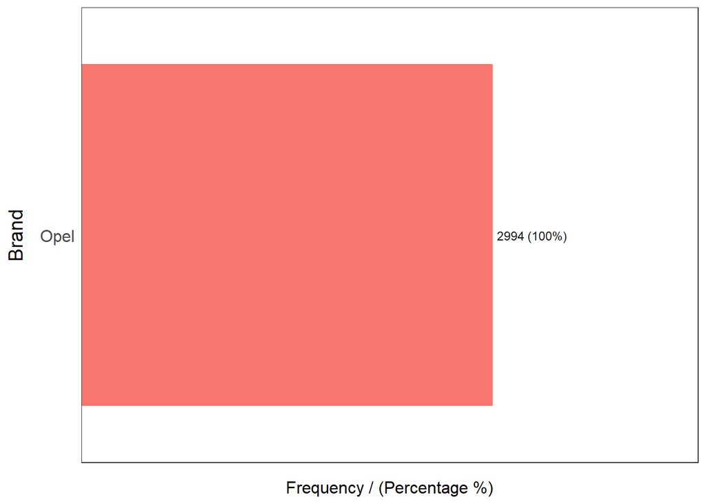

```
##   Brand frequency percentage cumulative_perc
## 1  Opel      2994        100             100
```

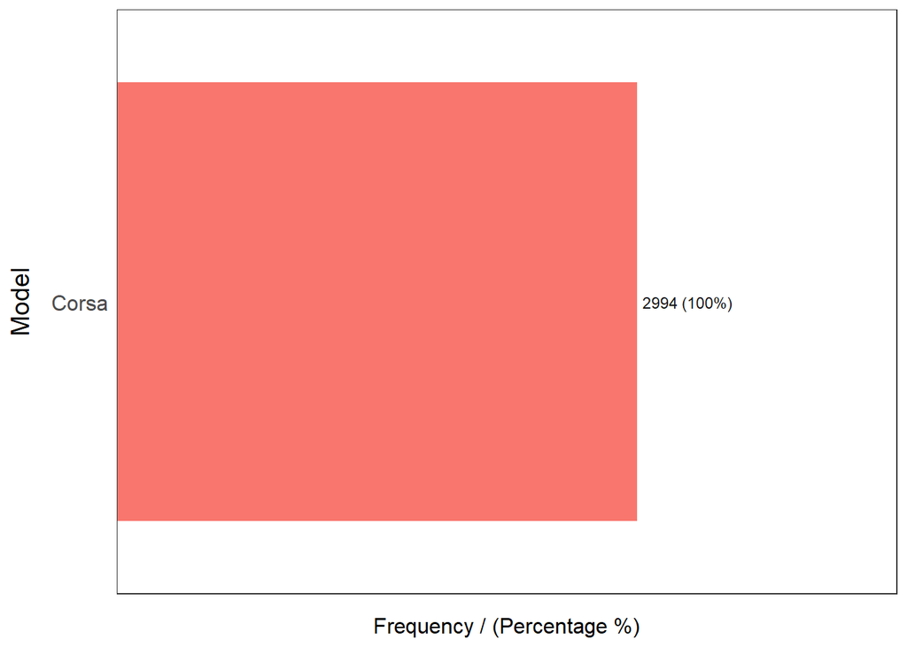

```
##   Model frequency percentage cumulative_perc
## 1 Corsa      2994        100             100
```

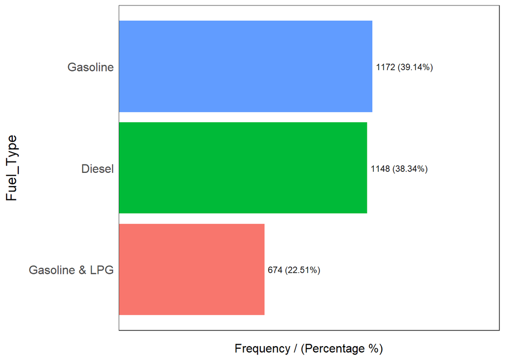

```
##        Fuel_Type frequency percentage cumulative_perc
## 1       Gasoline      1172      39.14           39.14
## 2         Diesel      1148      38.34           77.48
## 3 Gasoline & LPG       674      22.51          100.00
```

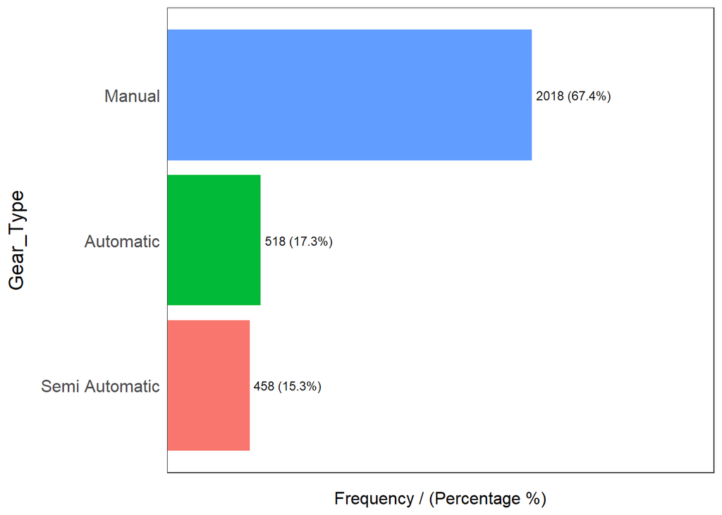

```
##        Gear_Type frequency percentage cumulative_perc
## 1         Manual      2018       67.4            67.4
## 2      Automatic       518       17.3            84.7
## 3 Semi Automatic       458       15.3           100.0
```

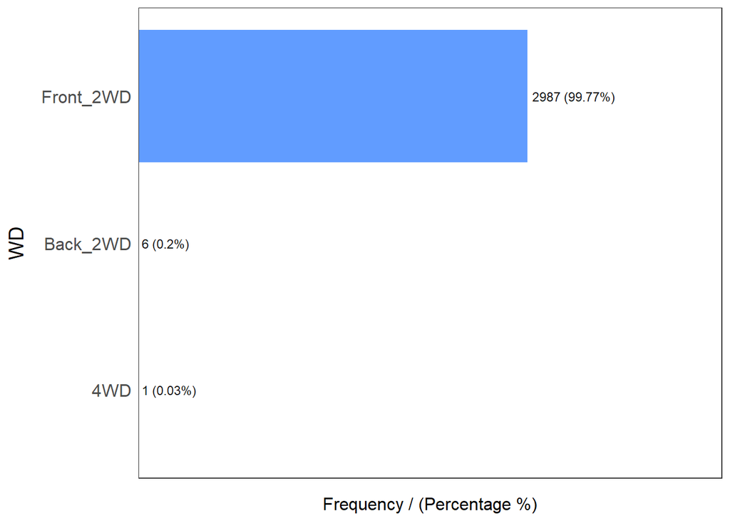

```
##          WD frequency percentage cumulative_perc
## 1 Front_2WD      2987      99.77           99.77
## 2  Back_2WD         6       0.20           99.97
## 3       4WD         1       0.03          100.00
```

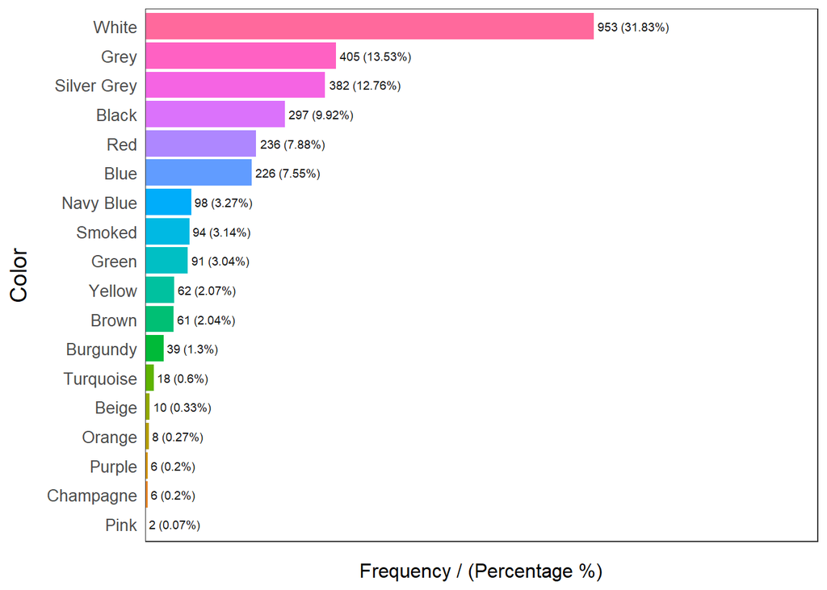

```
##          Color frequency percentage cumulative_perc
## 1        White       953      31.83           31.83
## 2         Grey       405      13.53           45.36
## 3  Silver Grey       382      12.76           58.12
## 4        Black       297       9.92           68.04
## 5          Red       236       7.88           75.92
## 6         Blue       226       7.55           83.47
## 7    Navy Blue        98       3.27           86.74
## 8       Smoked        94       3.14           89.88
## 9        Green        91       3.04           92.92
## 10      Yellow        62       2.07           94.99
## 11       Brown        61       2.04           97.03
## 12    Burgundy        39       1.30           98.33
## 13   Turquoise        18       0.60           98.93
## 14       Beige        10       0.33           99.26
## 15      Orange         8       0.27           99.53
## 16   Champagne         6       0.20           99.73
## 17      Purple         6       0.20           99.93
## 18        Pink         2       0.07          100.00
```

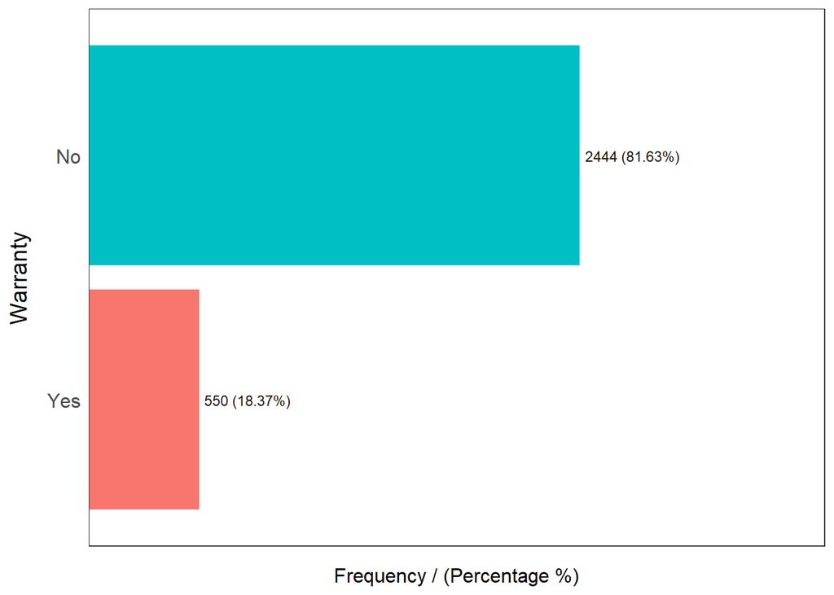

```
##   Warranty frequency percentage cumulative_perc
## 1       No      2444      81.63           81.63
## 2      Yes       550      18.37          100.00
```

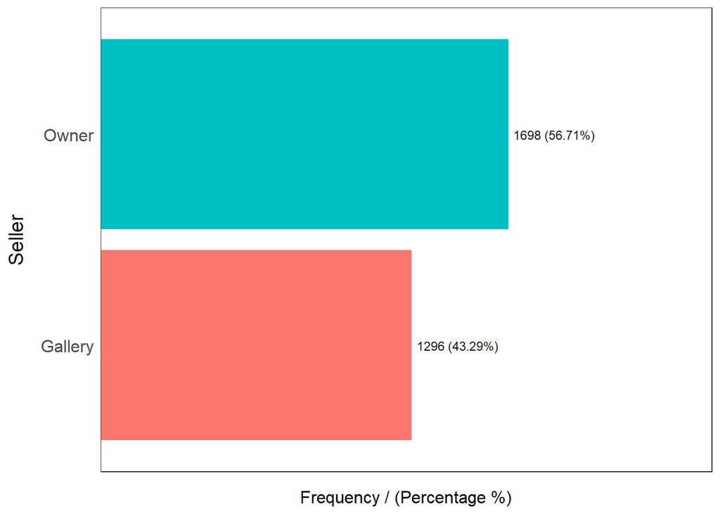

```
##    Seller frequency percentage cumulative_perc
## 1   Owner      1698      56.71           56.71
## 2 Gallery      1296      43.29          100.00
```

```
## [1] "Variables processed: Brand, Model, Fuel_Type, Gear_Type, WD, Color, Warranty, Seller"
```

```r
freq(cars)
```

### Plot_num

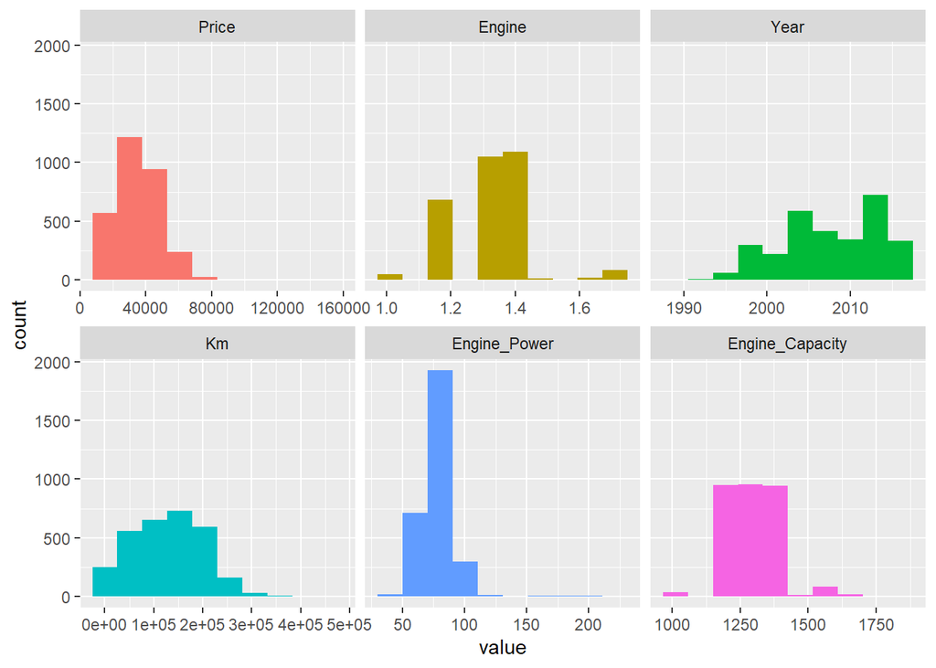

```r
plot_num(cars)
```

### Profiling_num

```r
profiling_num(cars)
```

```
##          variable         mean      std_dev variation_coef  p_01    p_05
## 1           Price 3.530798e+04 1.274661e+04     0.36101225 14250 17750.0
## 2          Engine 1.322779e+00 1.097129e-01     0.08294120     1     1.2
## 3            Year 2.007506e+03 5.922384e+00     0.00295012  1994  1997.0
## 4              Km 1.283223e+05 7.173726e+04     0.55903958  3000 17325.0
## 5    Engine_Power 7.976119e+01 1.535335e+01     0.19249152    51    51.0
## 6 Engine_Capacity 1.288937e+03 1.013122e+02     0.07860132   998  1199.0
##      p_25     p_50     p_75     p_95     p_99   skewness  kurtosis      iqr
## 1 25000.0  33900.0  43937.5  58500.0  67552.5  0.6486791  4.348960  18937.5
## 2     1.3      1.3      1.4      1.4      1.7  0.6368272  5.785257      0.1
## 3  2004.0   2008.0   2013.0   2016.0   2017.0 -0.3453788  2.098885      9.0
## 4 71000.0 130000.0 182000.0 240000.0 300000.0  0.2302952  2.662186 111000.0
## 5    75.0     76.0     90.0    100.0    126.0  2.0245987 17.960649     15.0
## 6  1229.0   1248.0   1364.0   1401.0   1601.0  0.9501447  5.528914    135.0
##                    range_98          range_80
## 1 [14250, 67552.5000000001]    [19750, 52000]
## 2                  [1, 1.7]        [1.2, 1.4]
## 3              [1994, 2017]      [1999, 2015]
## 4             [3000, 3e+05] [30000, 218918.1]
## 5                 [51, 126]          [60, 95]
## 6               [998, 1601]      [1201, 1398]
```

### Describe

```r
describe(cars)
```

```
## cars
##
##  14  Variables      2994  Observations
## --------------------------------------------------------------------------------
## Price
##        n  missing distinct     Info     Mean      Gmd      .05      .10
##     2994        0      498        1    35308    14336    17750    19750
##      .25      .50      .75      .90      .95
##    25000    33900    43938    52000    58500
##
## lowest :   7950   8250   9200   9900  10500, highest:  73750  74750  75000  75500 144750
## --------------------------------------------------------------------------------
## Brand
##        n  missing distinct    value
##     2994        0        1     Opel
##
## Value      Opel
## Frequency  2994
## Proportion    1
## --------------------------------------------------------------------------------
## Model
##        n  missing distinct    value
##     2994        0        1    Corsa
##
## Value      Corsa
## Frequency   2994
## Proportion     1
## --------------------------------------------------------------------------------
## Engine
##        n  missing distinct     Info     Mean      Gmd
##     2994        0        7    0.896    1.323   0.1108
##
## lowest : 1.0 1.2 1.3 1.4 1.5, highest: 1.3 1.4 1.5 1.6 1.7
##
## Value        1.0   1.2   1.3   1.4   1.5   1.6   1.7
## Frequency     48   684  1052  1094    14    20    82
## Proportion 0.016 0.228 0.351 0.365 0.005 0.007 0.027
## --------------------------------------------------------------------------------
## Year
##        n  missing distinct     Info     Mean      Gmd      .05      .10
```

[output cut: 76 more lines]

```
##        n  missing distinct
##     2994        0        2
##
## Value         No   Yes
## Frequency   2444   550
## Proportion 0.816 0.184
## --------------------------------------------------------------------------------
## Seller
##        n  missing distinct
##     2994        0        2
##
## Value      Gallery   Owner
## Frequency     1296    1698
## Proportion   0.433   0.567
## --------------------------------------------------------------------------------
```

## Data Visualization of Data

### Factor Hist

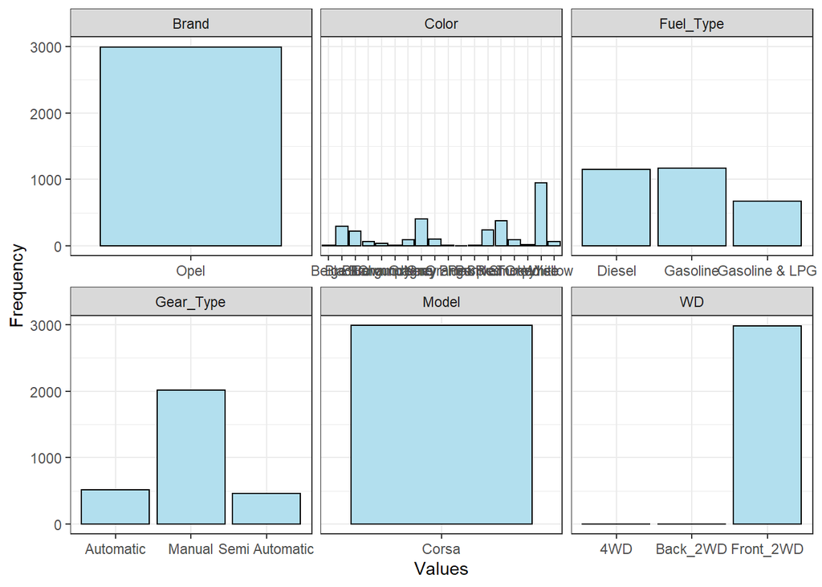

```r
cars %>% dplyr::select(where(is.factor)) %>%
  gather(attributes, value, 1:6) %>%
  ggplot(aes(x = value)) +
  geom_bar(fill = 'lightblue2', color = 'black') +
  facet_wrap(~attributes, scales = 'free_x') +
  labs(x="Values", y="Frequency") +
  theme_bw()
```

> From the `brand` and `model` feature plots, we can easily observe that these features have zero variance, so we can simply drop these columns in dimentionality reduction section.  
> `Fuel_Type`, `Gear_type` and `WD` seems to be categorical features!

### Numeric Hist

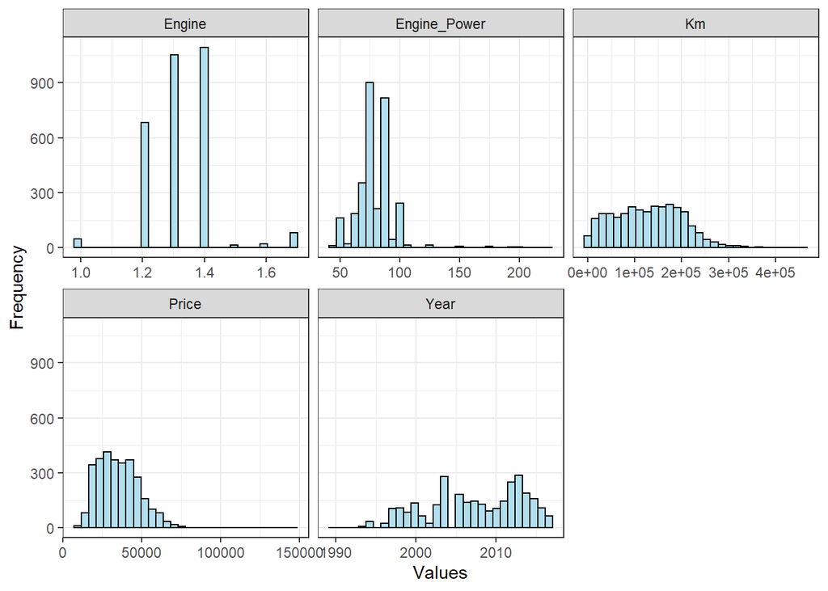

```r
cars %>% dplyr::select(where(is.numeric)) %>%
  gather(attributes, value, 1:5) %>%
  ggplot(aes(x = value)) +
  geom_histogram(fill = 'lightblue2', color = 'black') +
  facet_wrap(~attributes, scales = 'free_x') +
  labs(x="Values", y="Frequency") +
  theme_bw()
```

```r
cars$Engine <- as.factor(cars$Engine)
```

> `Engine` is a numeric column but it has only 7 unique value. So we can consider this feature as categorical one also.

### Upper Correlation Matrix

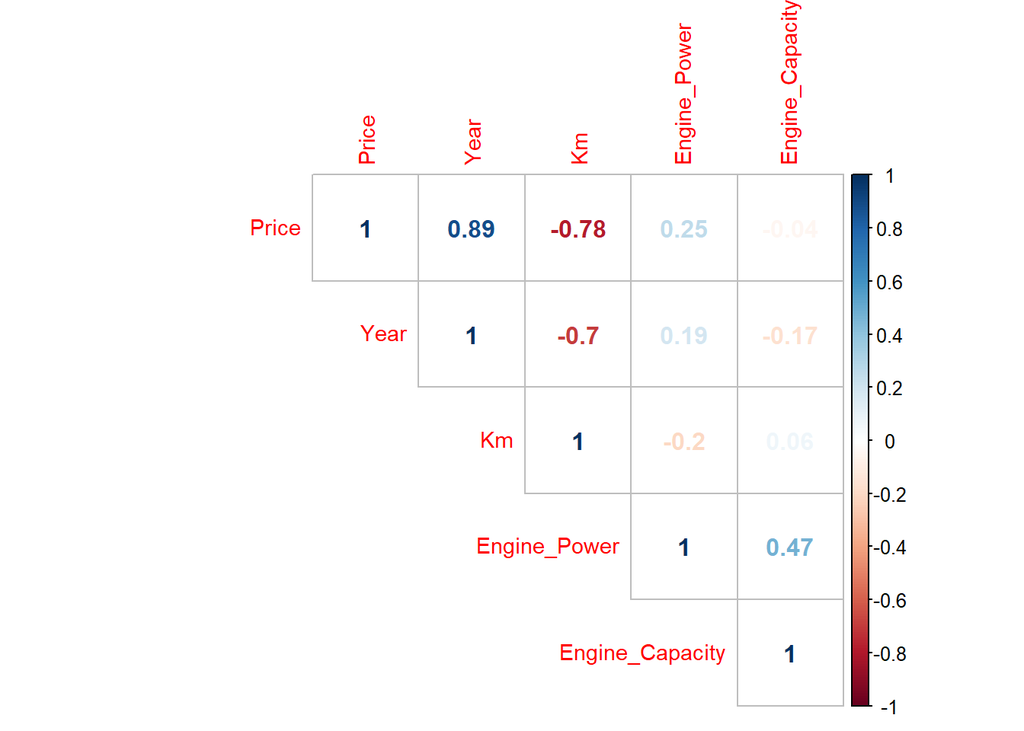

```r
corrplot(cor(cars %>% dplyr::select(where(is.numeric))), type = 'upper', method = 'number', tl.cex = 0.9)
```

### Price-Year Relation

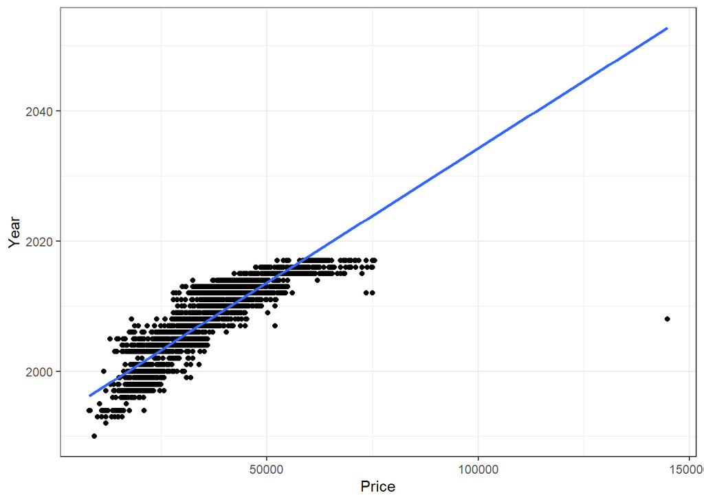

```r
ggplot(cars, aes(x = Price, y = Year)) +
  geom_point() +
  geom_smooth(method = 'lm', se = FALSE) +
  theme_bw()
```

```r
cars[cars$Price > 100000, ]$Price = median(cars$Price)
```

Let’s check it again

### Price-Year Relation After Outlier

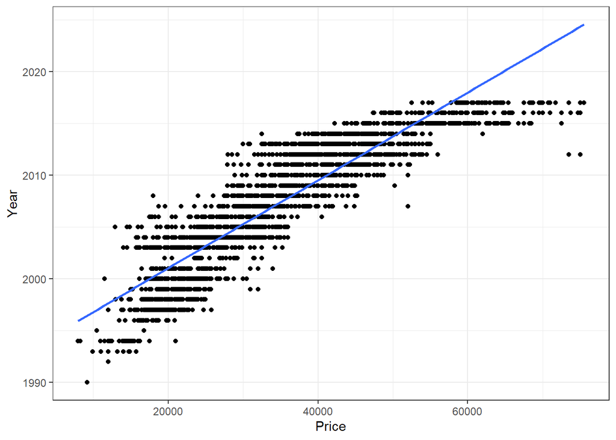

```r
ggplot(cars, aes(x = Price, y = Year)) +
  geom_point() +
  geom_smooth(method = 'lm', se = FALSE) +
  theme_bw()
```

Now it seems better :)

### Fuel-Type & Price Box Plot + Scatter Plot

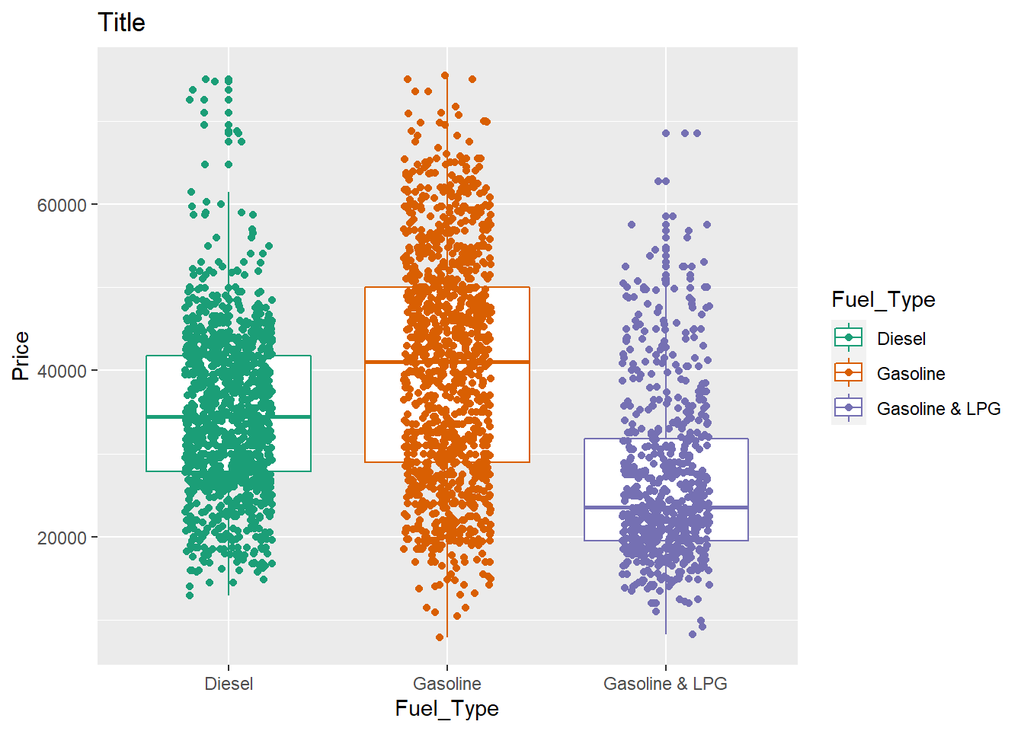

```r
ggplot(data = cars, aes(x=Fuel_Type, y=Price, color=Fuel_Type)) +
  geom_boxplot()+
  scale_color_brewer(palette="Dark2") +
  geom_jitter(shape=16, position=position_jitter(0.2))+
  labs(title = 'Title',
       y='Price',x='Fuel_Type')
```

> In this plot, we can observe that, `Gasoline type` cars are expensive then the rest.

### Year & Price, Fuel-TypeBox Plot + Gear-Type Scatter Plot

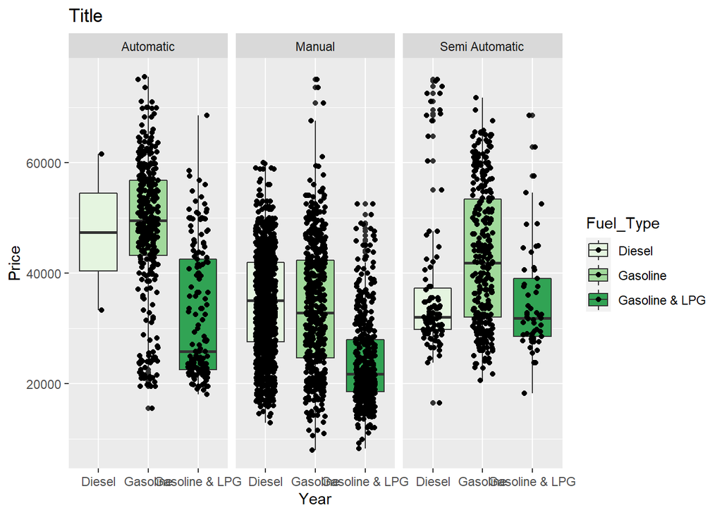

```r
ggplot(data = cars, aes(x=Fuel_Type,y=Price, fill=Fuel_Type)) +
  geom_boxplot()+
  scale_fill_brewer(palette="Green") +
  geom_jitter(shape=16, position=position_jitter(0.2))+
  labs(title = 'Title',
       y='Price',x='Year')+
  facet_wrap(~Gear_Type,nrow = 1)
```

### Year & Price, Fuel-TypeBox Plot + Year Scatter Plot

[figure not shown]

```r
ggplot(data = cars, aes(x=Fuel_Type,y=Price, fill=Fuel_Type)) +
  geom_boxplot()+
  scale_fill_brewer(palette="Green") +
  geom_jitter(shape=16, position=position_jitter(0.2))+
  labs(title = 'Title',
       y='Price',x='Year')+
  facet_wrap(~Year,nrow = 1)
```

> In this plot, we can observe that, `Year` and `price` have high positive correlation between each other.

> Create 3D plot to visualize most informative features `Price & Year & KM`

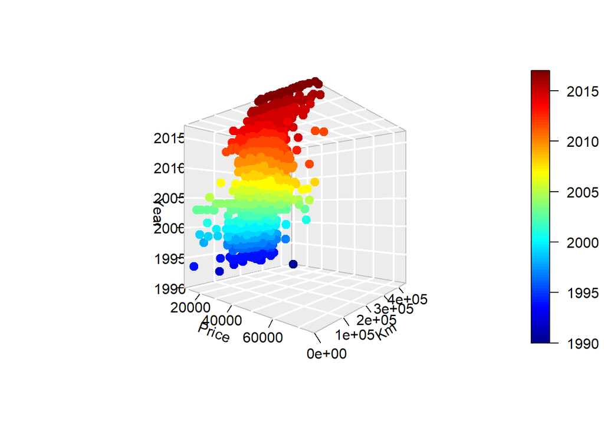

```r
# x, y, z variables
x <- cars$Price
y <- cars$Km
z <- cars$Engine_Capacity

scatter3D(cars$Price, cars$Km,cars$Year,
          xlab = "Price", ylab = "Km", zlab = "Year",
          phi = 0, bty = "g",pch = 20,cex = 2,
          ticktype = "detailed", colvar=as.numeric(cars$Year))
```

## Categorical Value Treatment & Data Normalization

Give index number to factor columns…

```r
car <- cars
indx <- sapply(car, is.factor)
car[indx] <- lapply(car[indx], function(x) as.numeric(factor(x)))
```

> To run the algorithms below, we need to use numerical values. These features are factor and simply given them some number to identify this factor values.

```r
kable(str(car))
```

```
## 'data.frame':    2994 obs. of  14 variables:
##  $ Price          : num  24900 27500 42500 63750 25000 ...
##  $ Brand          : num  1 1 1 1 1 1 1 1 1 1 ...
##  $ Model          : num  1 1 1 1 1 1 1 1 1 1 ...
##  $ Engine         : num  3 2 3 4 3 7 3 2 2 4 ...
##  $ Year           : int  2004 2004 2008 2017 2004 2003 2011 2000 2007 1999 ...
##  $ Fuel_Type      : num  1 2 1 2 1 1 1 2 2 3 ...
##  $ Gear_Type      : num  2 2 3 3 2 2 2 2 3 2 ...
##  $ Km             : int  270000 164000 300000 8780 200000 130000 197000 169000 97000 221000 ...
##  $ Engine_Power   : int  70 75 90 90 70 76 75 65 76 90 ...
##  $ Engine_Capacity: int  1248 1199 1248 1398 1248 1601 1248 1199 1201 1389 ...
##  $ WD             : num  3 3 3 3 3 3 3 3 3 3 ...
##  $ Color          : num  13 13 8 13 3 17 17 18 3 13 ...
##  $ Warranty       : num  1 1 1 2 1 2 1 1 1 1 ...
##  $ Seller         : num  1 1 1 1 2 1 1 1 2 2 ...
```

[output not shown]

```r
kable(head(car))
```

| Price | Brand | Model | Engine | Year | Fuel_Type | Gear_Type | Km | Engine_Power | Engine_Capacity | WD | Color | Warranty | Seller |
| --- | --- | --- | --- | --- | --- | --- | --- | --- | --- | --- | --- | --- | --- |
| 24900 | 1 | 1 | 3 | 2004 | 1 | 2 | 270000 | 70 | 1248 | 3 | 13 | 1 | 1 |
| 27500 | 1 | 1 | 2 | 2004 | 2 | 2 | 164000 | 75 | 1199 | 3 | 13 | 1 | 1 |
| 42500 | 1 | 1 | 3 | 2008 | 1 | 3 | 300000 | 90 | 1248 | 3 | 8 | 1 | 1 |
| 63750 | 1 | 1 | 4 | 2017 | 2 | 3 | 8780 | 90 | 1398 | 3 | 13 | 2 | 1 |
| 25000 | 1 | 1 | 3 | 2004 | 1 | 2 | 200000 | 70 | 1248 | 3 | 3 | 1 | 2 |
| 28500 | 1 | 1 | 7 | 2003 | 1 | 2 | 130000 | 76 | 1601 | 3 | 17 | 2 | 1 |

# Dimentionality Reduction

In the field of machine learning, it is useful to apply a process called dimensionality reduction to highly dimensional data. The purpose of this process is to reduce the number of features under consideration, where each feature is a dimension that partly represents the objects. Why is dimensionality reduction important? As more features are added, the data becomes very sparse and analysis suffers from the curse of dimensionality. Additionally, it is easier to process smaller data sets. Dimensionality reduction can be executed using two different methods:  
- Selecting from the existing features (feature selection)  
- Extracting new features by combining the existing features (feature extraction)

## Zero-Variance Analysis

```r
kable(profiling_num(car))
```

| variable | mean | std_dev | variation_coef | p_01 | p_05 | p_25 | p_50 | p_75 | p_95 | p_99 | skewness | kurtosis | iqr | range_98 | range_80 |
| --- | --- | --- | --- | --- | --- | --- | --- | --- | --- | --- | --- | --- | --- | --- | --- |
| Price | 3.527096e+04 | 1.258863e+04 | 0.3569120 | 14250 | 17750 | 25000 | 33900 | 43900 | 58500 | 67500 | 0.4626585 | 2.667568 | 18900 | [14250, 67500] | [19750, 52000] |
| Brand | 1.000000e+00 | 0.000000e+00 | 0.0000000 | 1 | 1 | 1 | 1 | 1 | 1 | 1 | NaN | NaN | 0 | [1, 1] | [1, 1] |
| Model | 1.000000e+00 | 0.000000e+00 | 0.0000000 | 1 | 1 | 1 | 1 | 1 | 1 | 1 | NaN | NaN | 0 | [1, 1] | [1, 1] |
| Engine | 3.243821e+00 | 1.056381e+00 | 0.3256595 | 1 | 2 | 3 | 3 | 4 | 4 | 7 | 0.9749908 | 5.589242 | 1 | [1, 7] | [2, 4] |
| Year | 2.007506e+03 | 5.922384e+00 | 0.0029501 | 1994 | 1997 | 2004 | 2008 | 2013 | 2016 | 2017 | -0.3453788 | 2.098885 | 9 | [1994, 2017] | [1999, 2015] |
| Fuel_Type | 1.841683e+00 | 7.639903e-01 | 0.4148326 | 1 | 1 | 1 | 2 | 2 | 3 | 3 | 0.2754706 | 1.756249 | 1 | [1, 3] | [1, 3] |
| Gear_Type | 1.979960e+00 | 5.706947e-01 | 0.2882355 | 1 | 1 | 2 | 2 | 2 | 3 | 3 | -0.0024646 | 3.067447 | 0 | [1, 3] | [1, 3] |
| Km | 1.283223e+05 | 7.173726e+04 | 0.5590396 | 3000 | 17325 | 71000 | 130000 | 182000 | 240000 | 300000 | 0.2302952 | 2.662186 | 111000 | [3000, 3e+05] | [30000, 218918.1] |
| Engine_Power | 7.976119e+01 | 1.535335e+01 | 0.1924915 | 51 | 51 | 75 | 76 | 90 | 100 | 126 | 2.0245987 | 17.960649 | 15 | [51, 126] | [60, 95] |
| Engine_Capacity | 1.288937e+03 | 1.013122e+02 | 0.0786013 | 998 | 1199 | 1229 | 1248 | 1364 | 1401 | 1601 | 0.9501447 | 5.528914 | 135 | [998, 1601] | [1201, 1398] |
| WD | 2.997328e+00 | 5.774070e-02 | 0.0192641 | 3 | 3 | 3 | 3 | 3 | 3 | 3 | -24.1633816 | 657.018707 | 0 | [3, 3] | [3, 3] |
| Color | 1.139646e+01 | 5.567746e+00 | 0.4885505 | 2 | 2 | 8 | 14 | 17 | 17 | 18 | -0.4894941 | 1.738998 | 9 | [2, 18] | [2, 17] |
| Warranty | 1.183701e+00 | 3.873046e-01 | 0.3271981 | 1 | 1 | 1 | 1 | 1 | 2 | 2 | 1.6336087 | 3.668677 | 0 | [1, 2] | [1, 2] |
| Seller | 1.567134e+00 | 4.955553e-01 | 0.3162175 | 1 | 1 | 1 | 2 | 2 | 2 | 2 | -0.2709909 | 1.073436 | 1 | [1, 2] | [1, 2] |

> There are two columns that have zero variance -> `Brand`, `Model`.  
> Drop these zero variance columns for dimension reduction.

```r
drops <- c("Brand","Model")
car <- car[ , !(names(car) %in% drops)]
kable(head(car))
```

| Price | Engine | Year | Fuel_Type | Gear_Type | Km | Engine_Power | Engine_Capacity | WD | Color | Warranty | Seller |
| --- | --- | --- | --- | --- | --- | --- | --- | --- | --- | --- | --- |
| 24900 | 3 | 2004 | 1 | 2 | 270000 | 70 | 1248 | 3 | 13 | 1 | 1 |
| 27500 | 2 | 2004 | 2 | 2 | 164000 | 75 | 1199 | 3 | 13 | 1 | 1 |
| 42500 | 3 | 2008 | 1 | 3 | 300000 | 90 | 1248 | 3 | 8 | 1 | 1 |
| 63750 | 4 | 2017 | 2 | 3 | 8780 | 90 | 1398 | 3 | 13 | 2 | 1 |
| 25000 | 3 | 2004 | 1 | 2 | 200000 | 70 | 1248 | 3 | 3 | 1 | 2 |
| 28500 | 7 | 2003 | 1 | 2 | 130000 | 76 | 1601 | 3 | 17 | 2 | 1 |

## Correlation Analysis

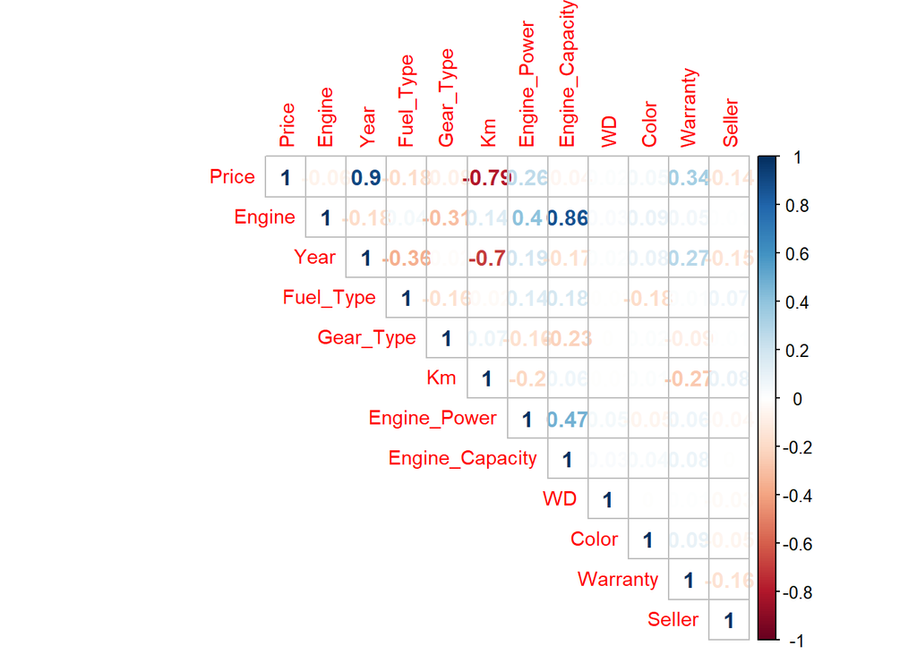

```r
corrplot(cor(car[sapply(car, is.numeric)]), type = 'upper', method = 'number', tl.cex = 0.9)
```

> From correlation analysis, there is a high correlation between Price and Year which is expected also Engine and Engine Capacity.  
> We can reduce dimentionality by using highly correlated features because if two features are highly correlated, then they have same effect from similar span in space to the machine learning model.  
> Candidates for dimentionality reduction are: `Price&Year` and `Engine&Engine_Capacity`. Let’s remove `Engine` and `Year` features from the data.

```r
car <- car[!names(car) %in% c("Engine","Year")]
kable(head(car))
```

| Price | Fuel_Type | Gear_Type | Km | Engine_Power | Engine_Capacity | WD | Color | Warranty | Seller |
| --- | --- | --- | --- | --- | --- | --- | --- | --- | --- |
| 24900 | 1 | 2 | 270000 | 70 | 1248 | 3 | 13 | 1 | 1 |
| 27500 | 2 | 2 | 164000 | 75 | 1199 | 3 | 13 | 1 | 1 |
| 42500 | 1 | 3 | 300000 | 90 | 1248 | 3 | 8 | 1 | 1 |
| 63750 | 2 | 3 | 8780 | 90 | 1398 | 3 | 13 | 2 | 1 |
| 25000 | 1 | 2 | 200000 | 70 | 1248 | 3 | 3 | 1 | 2 |
| 28500 | 1 | 2 | 130000 | 76 | 1601 | 3 | 17 | 2 | 1 |

## PCA(Principal Component Analysis)

In this chapter we are going to use PCA for dimentionality reduction.  
The main technique for feature extraction is the Principle Component Analysis (PCA). PCA guarantees finding the best linear transformation that reduces the number of dimensions with a minimum loss of information. Sometimes the information that was lost is regarded as noise – information that does not represent the phenomena we are trying to model, but is rather a side effect of some usually unknown processes. PCA process can be visualized as follows:

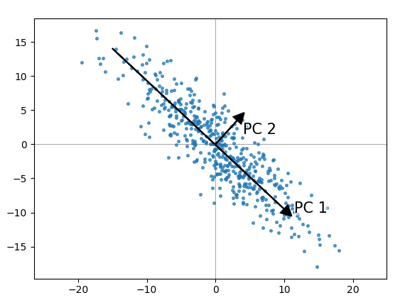

### Basic PCA

```r
res.pca <- PCA(car)
```

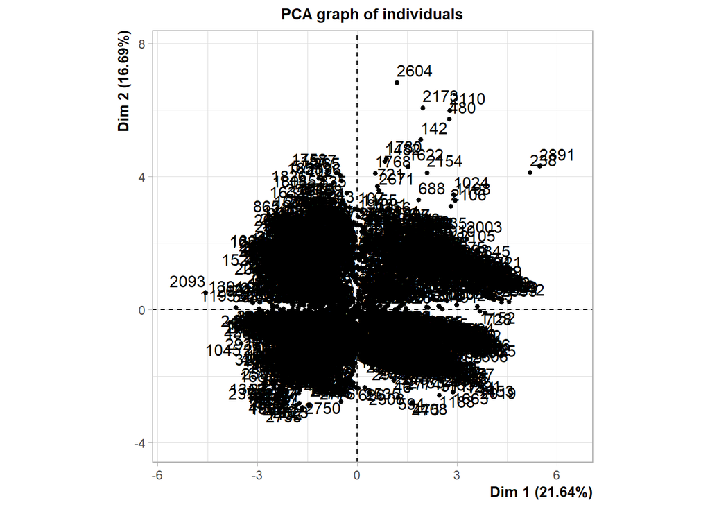

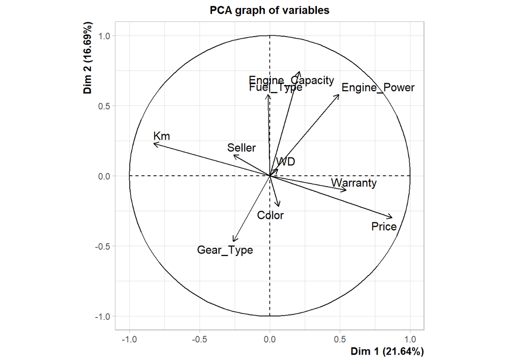

> In the PCA graph above, we can observe that `Engine_Capacity`, `Km` and `Price` are the best features to cover whole distribution.

### Extract Eigenvalue / Variance

Let’s find eigenvalue / variance of the data and show percentage of each feature.

```r
get_eig(res.pca)
```

```
##        eigenvalue variance.percent cumulative.variance.percent
## Dim.1   2.1644722        21.644722                    21.64472
## Dim.2   1.6687576        16.687576                    38.33230
## Dim.3   1.1506568        11.506568                    49.83887
## Dim.4   1.0095588        10.095588                    59.93445
## Dim.5   0.9767795         9.767795                    69.70225
## Dim.6   0.9006474         9.006474                    78.70872
## Dim.7   0.8095553         8.095553                    86.80428
## Dim.8   0.7098923         7.098923                    93.90320
## Dim.9   0.4378012         4.378012                    98.28121
## Dim.10  0.1718790         1.718790                   100.00000
```

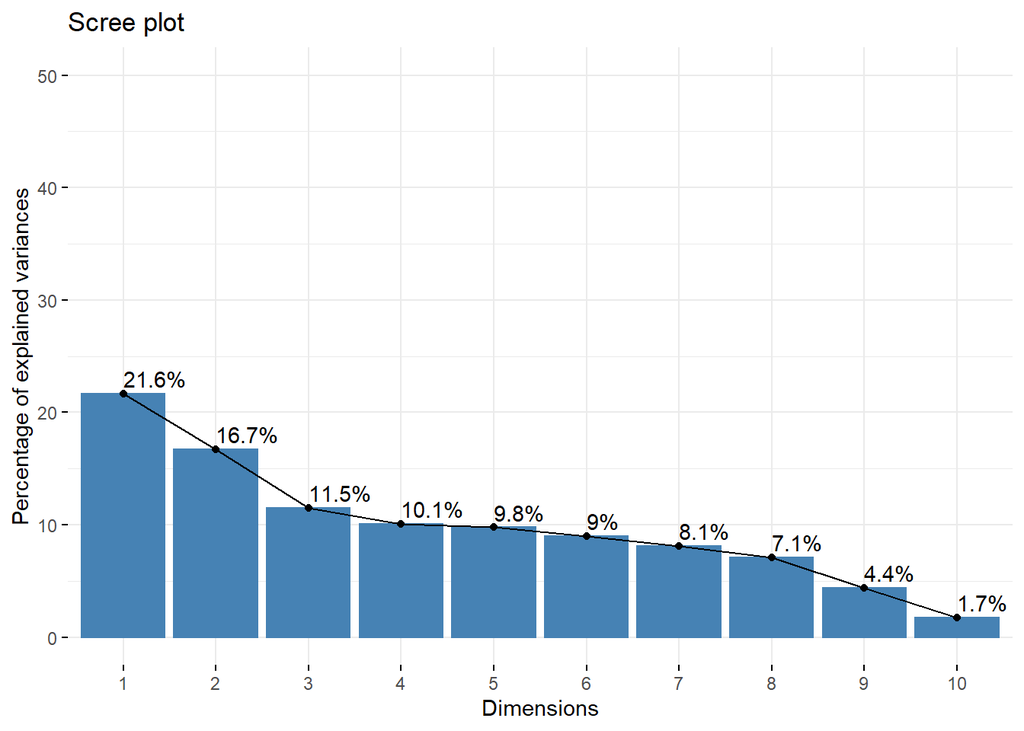

```r
fviz_screeplot(res.pca, addlabels = TRUE, ylim = c(0, 50))
```

**Extract the results for variables**  
Now let’s merge these eigenvalue results with feature names and see which features are more important than the others.

```r
var <- get_pca_var(res.pca)
# Coordinates of variables
kable(var$coord)
```

|  | Dim.1 | Dim.2 | Dim.3 | Dim.4 | Dim.5 |
| --- | --- | --- | --- | --- | --- |
| Price | 0.8718555 | -0.2988576 | -0.1361422 | 0.0353816 | 0.1660124 |
| Fuel_Type | -0.0121482 | 0.5814507 | -0.3883851 | -0.0949452 | -0.3446402 |
| Gear_Type | -0.2597633 | -0.4660614 | -0.0428322 | 0.2357834 | 0.1587561 |
| Km | -0.8257640 | 0.2318551 | 0.3166230 | -0.0158091 | -0.1115312 |
| Engine_Power | 0.4916763 | 0.5797274 | 0.0860130 | 0.1487164 | 0.2790065 |
| Engine_Capacity | 0.2112345 | 0.7433600 | 0.3590415 | -0.0137531 | 0.1458924 |
| WD | 0.0562266 | 0.0496148 | 0.1630968 | 0.9134135 | -0.1052629 |
| Color | 0.0630850 | -0.2169561 | 0.7436052 | -0.2137706 | 0.2544330 |
| Warranty | 0.5427151 | -0.1010429 | 0.1773395 | -0.1953049 | -0.3648084 |
| Seller | -0.2584240 | 0.1482482 | -0.3631621 | -0.0545596 | 0.6962536 |

```r
# Contribution of variables
kable(var$contrib)
```

|  | Dim.1 | Dim.2 | Dim.3 | Dim.4 | Dim.5 |
| --- | --- | --- | --- | --- | --- |
| Price | 35.1185872 | 5.3522369 | 1.6107934 | 0.1240004 | 2.821528 |
| Fuel_Type | 0.0068182 | 20.2596767 | 13.1092968 | 0.8929233 | 12.160050 |
| Gear_Type | 3.1174798 | 13.0164648 | 0.1594393 | 5.5067415 | 2.580266 |
| Km | 31.5035808 | 3.2213666 | 8.7124279 | 0.0247561 | 1.273491 |
| Engine_Power | 11.1687989 | 20.1397679 | 0.6429574 | 2.1907155 | 7.969517 |
| Engine_Capacity | 2.0614740 | 33.1135057 | 11.2032380 | 0.0187356 | 2.179058 |
| WD | 0.1460601 | 0.1475126 | 2.3117737 | 82.6424692 | 1.134368 |
| Color | 0.1838654 | 2.8206573 | 48.0550488 | 4.5265188 | 6.627507 |
| Warranty | 13.6079195 | 0.6118120 | 2.7331609 | 3.7782829 | 13.624891 |
| Seller | 3.0854160 | 1.3169994 | 11.4618637 | 0.2948567 | 49.629324 |

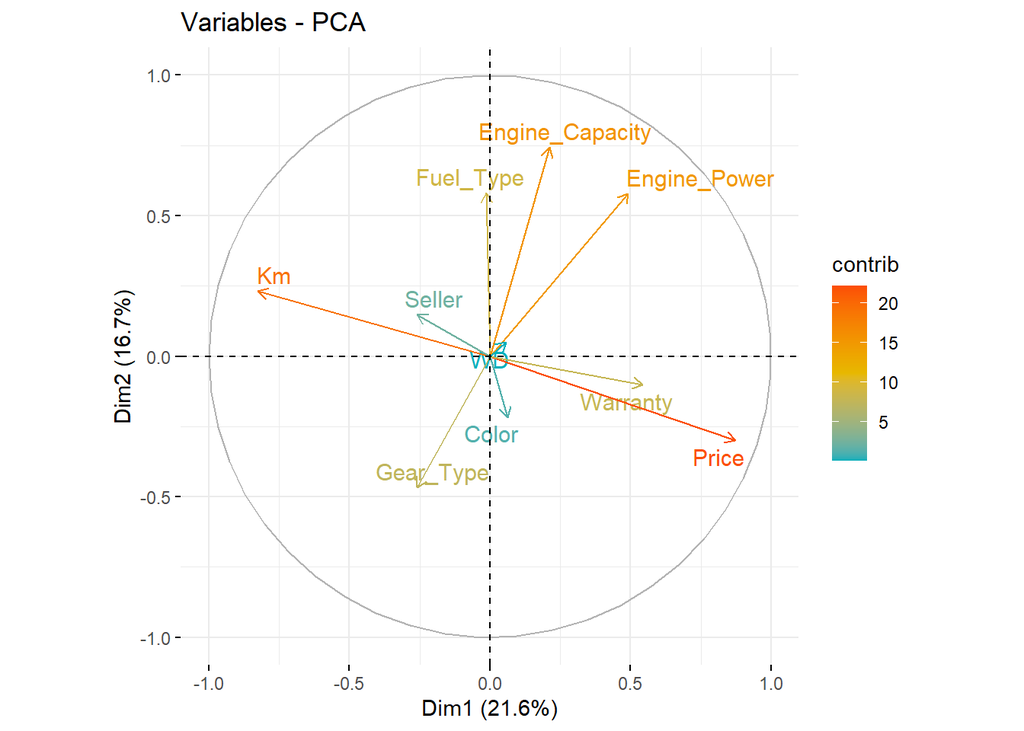

```r
# Control variable colors using their contributions
fviz_pca_var(res.pca, col.var="contrib",
             gradient.cols = c("#00AFBB", "#E7B800", "#FC4E07"),
             repel = TRUE # Avoid text overlapping
)
```

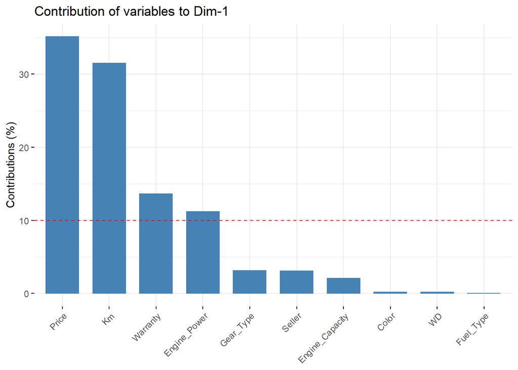

```r
# Contributions of variables to PC1
fviz_contrib(res.pca, choice = "var", axes = 1, top = 10)
```

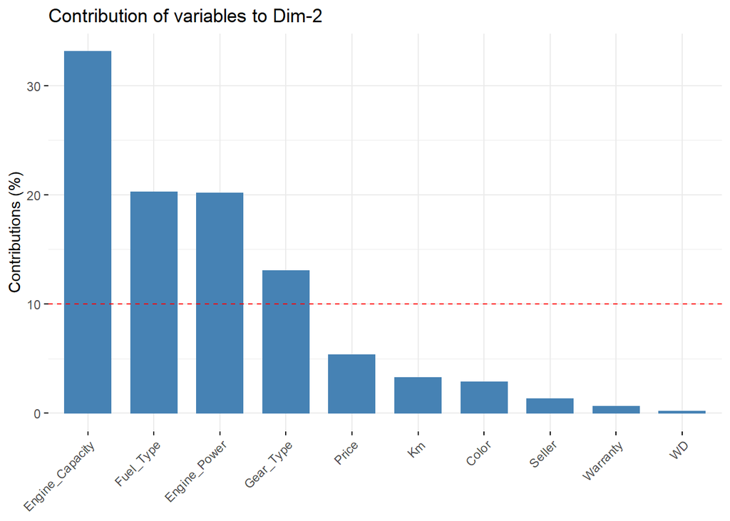

```r
# Contributions of variables to PC2
fviz_contrib(res.pca, choice = "var", axes = 2, top = 10)
```

**Extract the results for individuals**  
Let’s find results for individuals.

```r
ind <- get_pca_ind(res.pca)
# Coordinates of individuals
kable(head(ind$coord))
```

| Dim.1 | Dim.2 | Dim.3 | Dim.4 | Dim.5 |
| --- | --- | --- | --- | --- |
| -1.8244337 | -0.6222581 | 1.4147255 | 0.0988391 | -0.7726425 |
| -0.8439338 | -0.4782340 | 0.3425005 | 0.0604904 | -1.0071373 |
| -1.1430736 | -0.7674374 | 0.7725699 | 0.9366888 | -0.1668707 |
| 3.3292843 | -0.7982184 | 0.4310606 | 0.2229979 | -0.3849839 |
| -1.7034901 | -0.2659470 | -0.8029131 | 0.3870671 | 0.2982094 |
| 1.0550205 | 0.8193233 | 2.9250885 | -0.5050588 | -0.6477896 |

```r
# Contribution of variables
kable(head(ind$contrib))
```

| Dim.1 | Dim.2 | Dim.3 | Dim.4 | Dim.5 |
| --- | --- | --- | --- | --- |
| 0.0513632 | 0.0077499 | 0.0580961 | 0.0003232 | 0.0204131 |
| 0.0109904 | 0.0045776 | 0.0034051 | 0.0001211 | 0.0346840 |
| 0.0201625 | 0.0117880 | 0.0173252 | 0.0290273 | 0.0009522 |
| 0.1710401 | 0.0127526 | 0.0053936 | 0.0016452 | 0.0050680 |
| 0.0447791 | 0.0014156 | 0.0187128 | 0.0049567 | 0.0030408 |
| 0.0171758 | 0.0134359 | 0.2483593 | 0.0084392 | 0.0143489 |

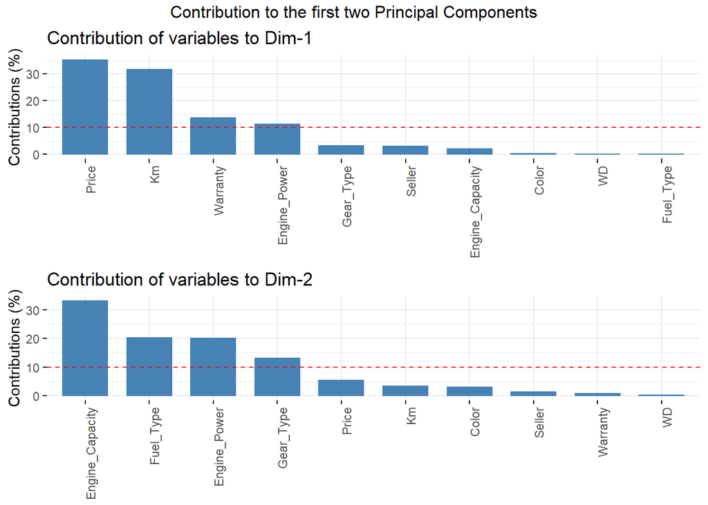

```r
var<-get_pca_var(res.pca)
a<-fviz_contrib(res.pca, "var", axes=1, xtickslab.rt=90) # default angle=45°
b<-fviz_contrib(res.pca, "var", axes=2, xtickslab.rt=90)
grid.arrange(a,b,top='Contribution to the first two Principal Components')
```

**RESULT FOR PCA**

> As a result from the contributions graphs above, both in results for variables and results for individual case, we can simply drop `WD`, `Color` and `Seller` features from the dataset. Since we improve our data complexity, we won’t loose much accuracy with clustering the data which is a desired case for dimentionality reduction.

```r
car <- car[!names(car) %in% c("WD", "Color","Seller")]
kable(head(car))
```

| Price | Fuel_Type | Gear_Type | Km | Engine_Power | Engine_Capacity | Warranty |
| --- | --- | --- | --- | --- | --- | --- |
| 24900 | 1 | 2 | 270000 | 70 | 1248 | 1 |
| 27500 | 2 | 2 | 164000 | 75 | 1199 | 1 |
| 42500 | 1 | 3 | 300000 | 90 | 1248 | 1 |
| 63750 | 2 | 3 | 8780 | 90 | 1398 | 2 |
| 25000 | 1 | 2 | 200000 | 70 | 1248 | 1 |
| 28500 | 1 | 2 | 130000 | 76 | 1601 | 2 |

# Clustering

In this chapter we are going to use K-Means, PAM and Hierarchical clustering methods.  
Clustering is the task of dividing the population or data points into a number of groups such that data points in the same groups are more similar to other data points in the same group than those in other groups. In simple words, the aim is to segregate groups with similar traits and assign them into clusters.

## K-MEANS

There are many clustering algorithms, each has its advantages and disadvantages. A popular algorithm for clustering is k-means, which aims to identify the best k cluster centers in an iterative manner. Cluster centers are served as “representative” of the objects associated with the cluster. k-means’ key features are also its drawbacks:  
- The number of clusters (k) must be given explicitly. In some cases, the number of different groups is unknown.  
- k-means iterative nature might lead to an incorrect result due to convergence to a local minimum.  
- The clusters are assumed to be spherical.  
Despite these drawbacks, k-means remains the right and popular choice in many cases. An example for clustering using k-means on spherical data can be seen in Figure.

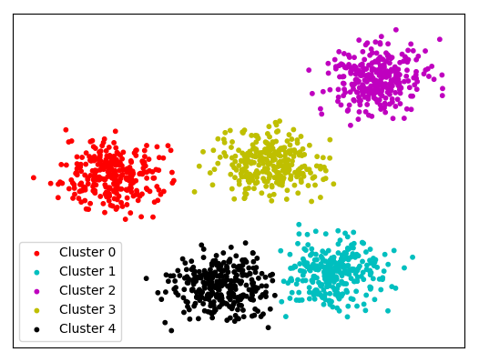

### K-Means With Different Center Points

Let’s compare k-means with `k = [2,3,4,5]`

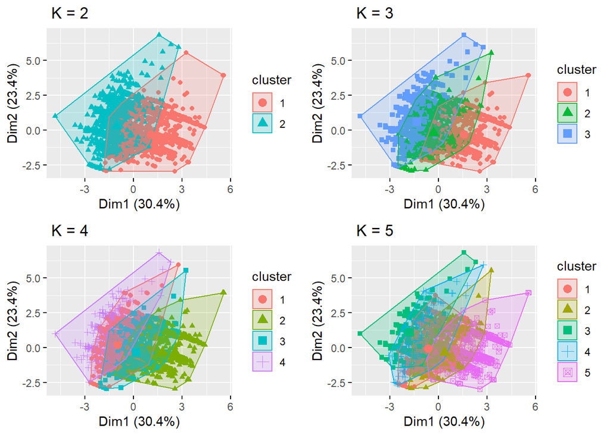

```r
set.seed(123)
cars_K2 <- kmeans(car, centers = 2, nstart = 25)
cars_K3 <- kmeans(car, centers = 3, nstart = 25)
cars_K4 <- kmeans(car, centers = 4, nstart = 25)
cars_K5 <- kmeans(car, centers = 5, nstart = 25)
p1 <- fviz_cluster(cars_K2, geom = "point", data = car) + ggtitle(" K = 2")
p2 <- fviz_cluster(cars_K3, geom = "point", data = car) + ggtitle(" K = 3")
p3 <- fviz_cluster(cars_K4, geom = "point", data = car) + ggtitle(" K = 4")
p4 <- fviz_cluster(cars_K5, geom = "point", data = car) + ggtitle(" K = 5")
grid.arrange(p1, p2, p3, p4, nrow = 2)
```

### Find Optimal Number of Clusters K

Let’s compare number of clusters with `Silhouette` and `Elbow` Graphs

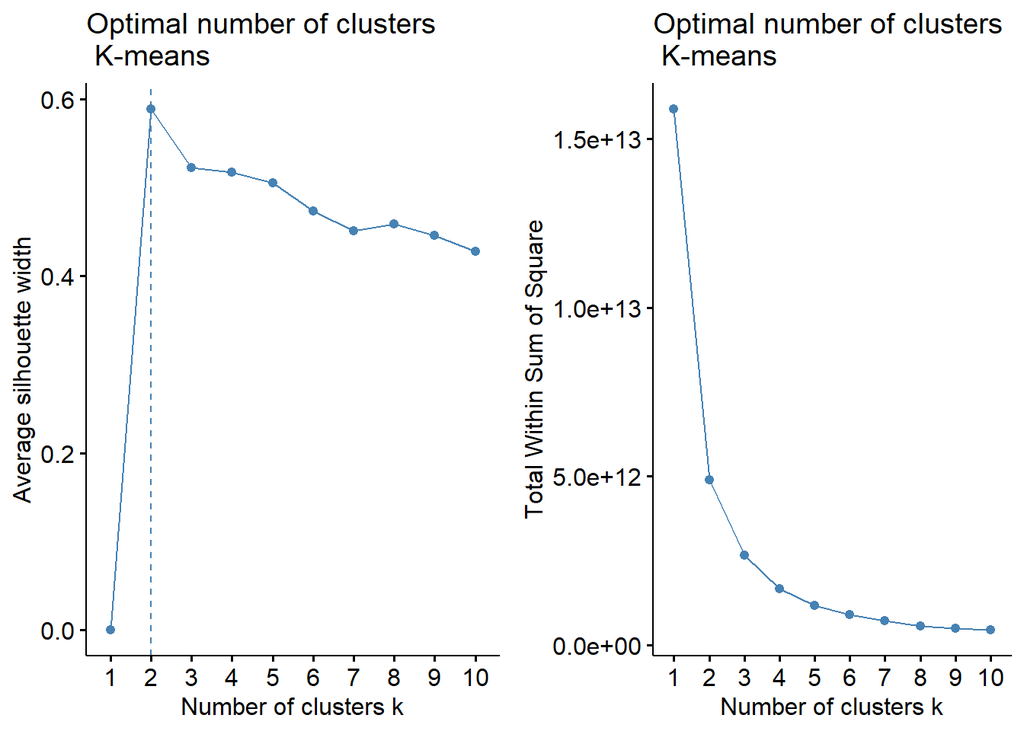

```r
f1 <- fviz_nbclust(car, FUNcluster = kmeans, method = "silhouette") +
  ggtitle("Optimal number of clusters \n K-means")
f2 <- fviz_nbclust(car, FUNcluster = kmeans, method = "wss") +
  ggtitle("Optimal number of clusters \n K-means")
grid.arrange(f1, f2, ncol=2)
```

> From `Silhouette` and `Elbow` graphs, we can observe that there are 2 candidate for number of clusters as `2` or `3`. Let’s deep dive into the number of clusters with 2 and 3.